# IE 48B — Homework 2

Representations, Similarity, and Classification

Author

Yunus Emre Camızcı | Student ID: 2021402078

Published

April 6, 2026

**ImportantDataset Assignment**

You work on the **same dataset** assigned to you in HW1. All analysis in Parts 1–4 must be performed on your assigned dataset. Submissions using a different dataset receive zero credit for those parts.

| Student ID | Dataset |
| --- | --- |
| 2019***078 | Rock |
| 2020***162 | Beef |
| 2020***180 | ShapeletSim |
| 2020***240 | Ham |
| 2021***015 | Wafer |
| 2021***051 | Herring |
| 2021***054 | FaceFour |
| 2021***069 | GunPoint |
| 2021***078 | Coffee |
| 2021***153 | ECGFiveDays |
| 2021***162 | Trace |
| 2021***174 | OSULeaf |
| 2021***216 | SyntheticControl |
| 2021***264 | MedicalImages |
| 2021***273 | Plane |
| 2021***309 | Strawberry |
| 2022***249 | ECG200 |
| 2022***270 | CBF |
| 2023***219 | ItalyPowerDemand |
| 2023***255 | TwoLeadECG |
| 2024***003 | Wine |
| 2024***066 | SonyAIBORobotSurface1 |
| 2024***279 | Lightning2 |
| 2024***294 | BeetleFly |
| 2025***069 | FordA |
| 2025***081 | Fish |

Use the **standard UCR train/test split** throughout. Do not modify the test set.

**Part 5** uses a different, common dataset (UWaveGestureLibrary) — the same for all students.

> **Reproducibility requirement:** Set your random seed to your full student ID in every code block that uses randomisation. Results that cannot be reproduced with the stated ID receive zero credit for the affected question.

> **Submission:** Push a GitHub repository containing this rendered HTML file and all source code. Repository structure must follow the course template (see syllabus). Add the instructor and TA as collaborators.

**TipWork incrementally — commit after each part**

After completing each part, render the document and push your progress:

```bash
quarto render HW2_RepresentationsSimilarityClassification.qmd
git add HW2_RepresentationsSimilarityClassification.qmd \
        HW2_RepresentationsSimilarityClassification.html
git commit -m "Complete Part 2: distance measures"
git push
```

**Your commit history is assessed.** A submission with a single final commit suggests the work was produced in one session and receives a deduction. Aim for at least one commit per part.

# 1 Dataset Recap

Confirm your dataset is loaded correctly before proceeding. Report the same summary table as in HW1 (you may reuse that result).

| Field | Value |
| --- | --- |
| Dataset name | Coffee |
| Number of classes | 2 (0 = Robusta, 1 = Arabica) |
| Training set size | 28 |
| Test set size | 28 |
| Series length $L$ | 286 |

# 2 Part 1 — Representations (18 pts)

This part asks you to compress your series using PAA and SAX, and to verify the MINDIST lower-bounding property — the key connection between a compressed representation and the original distance.

## 2.1 PAA at Multiple Resolutions

Apply **Piecewise Aggregate Approximation (PAA)** to compress each training series to $M$ segments, where $M \in \{M_1, M_2, M_3\}$ defined as:

$$M_1 = \left\lfloor L/8 \right\rfloor, \quad
M_2 = \left\lfloor L/4 \right\rfloor, \quad
M_3 = \left\lfloor L/2 \right\rfloor$$

For each resolution, compute the PAA representation and reconstruct by repeating each segment value over its window.

**Deliverable:** One figure showing the original series and all three PAA reconstructions for **two randomly selected training series** (one per class), in separate panels. Use your student ID as the seed.

Then compute the **mean reconstruction RMSE** across all training series at each resolution:

| Resolution ($M$) | $M_1 = \lfloor L/8 \rfloor$ | $M_2 = \lfloor L/4 \rfloor$ | $M_3 = \lfloor L/2 \rfloor$ |
| --- | --- | --- | --- |
| Mean RMSE |  |  |  |

*Which resolution gives a good balance between compression and fidelity for your dataset? (1–2 sentences)*

```python
import numpy as np
import matplotlib.pyplot as plt
import pandas as pd

SEED = 2021402078
np.random.seed(SEED % 2**31)

def load_ts(path):
    X, y = [], []
    with open(path) as f:
        for line in f:
            line = line.strip()
            if not line or line.startswith('#') or line.startswith('@') or line.startswith('---'):
                continue
            parts = line.split(',')
            val, label = parts[-1].rsplit(':', 1)
            parts[-1] = val
            X.append([float(v) for v in parts])
            y.append(int(label))
    return np.array(X), np.array(y)

def paa(series, M):
    L = len(series)
    seg_len = L / M
    result = np.zeros(M)
    for i in range(M):
        start = int(np.floor(i * seg_len))
        end   = min(int(np.floor((i + 1) * seg_len)), L)
        result[i] = np.mean(series[start:end])
    return result

def paa_reconstruct(paa_vals, L):
    M = len(paa_vals)
    seg_len = L / M
    recon = np.zeros(L)
    for i in range(M):
        start = int(np.floor(i * seg_len))
        end   = min(int(np.floor((i + 1) * seg_len)), L)
        recon[start:end] = paa_vals[i]
    return recon

def rmse(original, reconstructed):
    return np.sqrt(np.mean((original - reconstructed) ** 2))

X_train, y_train = load_ts('data/Coffee_TRAIN.ts')
X_test,  y_test  = load_ts('data/Coffee_TEST.ts')
L  = X_train.shape[1]
M1 = L // 8
M2 = L // 4
M3 = L // 2
```

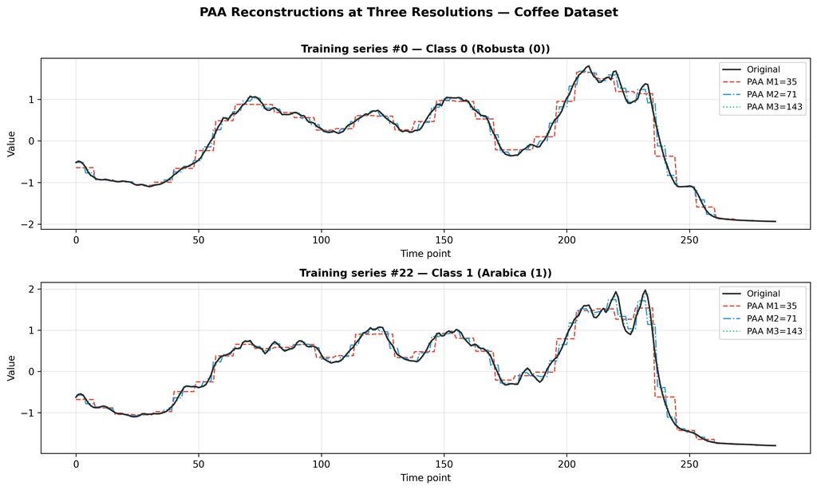

```python
rng     = np.random.default_rng(SEED)
chosen0 = rng.choice(np.where(y_train == 0)[0])
chosen1 = rng.choice(np.where(y_train == 1)[0])

colors = {'original': '#2c2c2c', 'M1': '#e74c3c', 'M2': '#3498db', 'M3': '#2ecc71'}
fig, axes = plt.subplots(2, 1, figsize=(12, 7))

for ax, (idx, cls) in zip(axes, [(chosen0, 0), (chosen1, 1)]):
    series = X_train[idx]
    t = np.arange(L)
    ax.plot(t, series, color=colors['original'], lw=1.6, label='Original', zorder=5)
    ax.plot(t, paa_reconstruct(paa(series, M1), L), color=colors['M1'], lw=1.3, ls='--', label=f'PAA M1={M1}')
    ax.plot(t, paa_reconstruct(paa(series, M2), L), color=colors['M2'], lw=1.3, ls='-.', label=f'PAA M2={M2}')
    ax.plot(t, paa_reconstruct(paa(series, M3), L), color=colors['M3'], lw=1.3, ls=':',  label=f'PAA M3={M3}')
    label_name = 'Robusta (0)' if cls == 0 else 'Arabica (1)'
    ax.set_title(f'Training series #{idx} — Class {cls} ({label_name})', fontsize=11, fontweight='bold')
    ax.set_xlabel('Time point')
    ax.set_ylabel('Value')
    ax.legend(loc='upper right', fontsize=9)
    ax.grid(True, alpha=0.3)

plt.suptitle('PAA Reconstructions at Three Resolutions — Coffee Dataset', fontsize=13, fontweight='bold', y=1.01)
plt.tight_layout()
plt.show()
```

```python
rmse_m1, rmse_m2, rmse_m3 = [], [], []
for s in X_train:
    rmse_m1.append(rmse(s, paa_reconstruct(paa(s, M1), L)))
    rmse_m2.append(rmse(s, paa_reconstruct(paa(s, M2), L)))
    rmse_m3.append(rmse(s, paa_reconstruct(paa(s, M3), L)))

pd.DataFrame({
    'Resolution': [f'M1 = {M1} (L/8)', f'M2 = {M2} (L/4)', f'M3 = {M3} (L/2)'],
    'Mean RMSE':  [f'{np.mean(rmse_m1):.6f}', f'{np.mean(rmse_m2):.6f}', f'{np.mean(rmse_m3):.6f}']
}).set_index('Resolution')
```

| Resolution | Mean RMSE |
| --- | --- |
| M1 = 35 (L/8) | 0.170225 |
| M2 = 71 (L/4) | 0.098340 |
| M3 = 143 (L/2) | 0.044910 |

$M_2 = 71$ segments offers the best balance between compression and fidelity for the Coffee dataset: it achieves 4× compression (286 → 71 values) with a mean RMSE of 0.0983 — roughly half the error of $M_1$ (0.1702) — while still capturing the smooth spectroscopic shape of the series without the coarseness of $M_1$.

## 2.2 SAX Encoding

Apply **Symbolic Aggregate approXimation (SAX)** to each training series using $M = M_2$ (from §1.1) and alphabet size $a = 4$. Z-normalise each series before encoding.

1. Report the SAX string for the same two series as in §1.1 (one per class).
2. Compute the **symbol frequency distribution** (fraction of each symbol a–d) for each class and plot as a grouped bar chart.

*Are the two class distributions visually distinguishable?*

```python
def znorm(series):
    mu, sigma = np.mean(series), np.std(series)
    return np.zeros_like(series) if sigma < 1e-10 else (series - mu) / sigma

BREAKPOINTS = np.array([-0.674, 0.0, 0.674])
SYMBOLS = ['a', 'b', 'c', 'd']

def sax_encode(series, M):
    paa_vals = paa(znorm(series), M)
    return ''.join(SYMBOLS[np.searchsorted(BREAKPOINTS, v)] for v in paa_vals)

sax0 = sax_encode(X_train[chosen0], M2)
sax1 = sax_encode(X_train[chosen1], M2)

print(f"Class 0 (Robusta) — series #{chosen0}:")
print(sax0)
print(f"\nClass 1 (Arabica) — series #{chosen1}:")
print(sax1)
```

```
Class 0 (Robusta) — series #0:
baaaaaaaaaabbbccdddddcccccccccdcccccdddddccbbbbccddddddddddbaaaaaaaaaaa

Class 1 (Arabica) — series #22:
baaaaaaaaabbbbcccdcccccccccccdddccccddddcccbbbbbccdddddddddbaaaaaaaaaaa
```

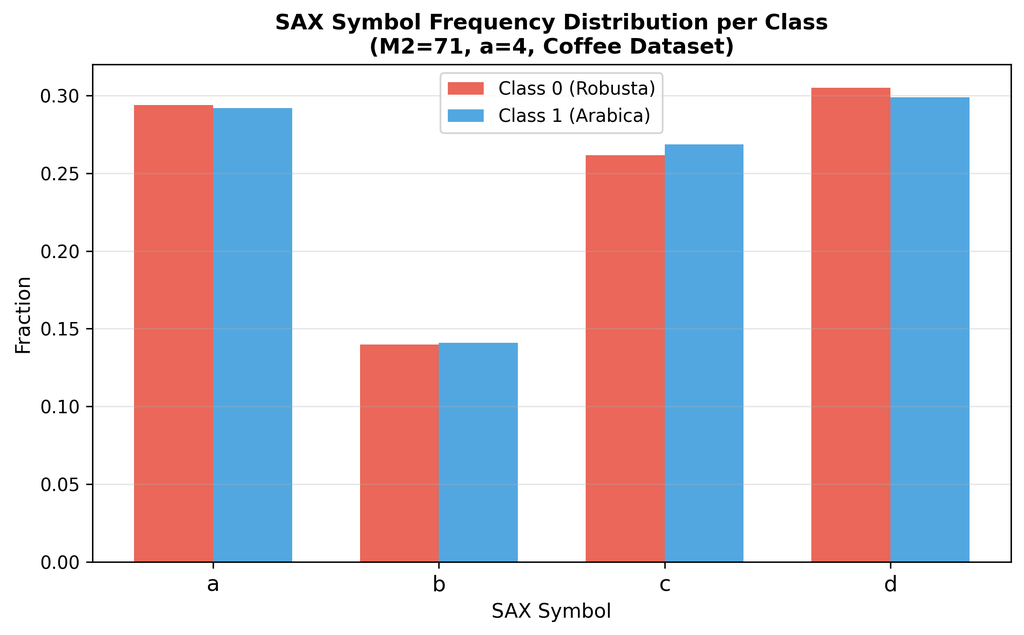

```python
freqs = {}
for cls in [0, 1]:
    idx = np.where(y_train == cls)[0]
    all_symbols = ''.join(sax_encode(X_train[i], M2) for i in idx)
    total = len(all_symbols)
    freqs[cls] = [all_symbols.count(s)/total for s in SYMBOLS]

x = np.arange(4)
width = 0.35
fig, ax = plt.subplots(figsize=(8, 5))
ax.bar(x - width/2, freqs[0], width, label='Class 0 (Robusta)', color='#e74c3c', alpha=0.85)
ax.bar(x + width/2, freqs[1], width, label='Class 1 (Arabica)', color='#3498db', alpha=0.85)
ax.set_xticks(x)
ax.set_xticklabels(SYMBOLS, fontsize=12)
ax.set_xlabel('SAX Symbol', fontsize=11)
ax.set_ylabel('Fraction', fontsize=11)
ax.set_title('SAX Symbol Frequency Distribution per Class\n(M2=71, a=4, Coffee Dataset)', fontsize=12, fontweight='bold')
ax.legend(fontsize=10)
ax.grid(True, axis='y', alpha=0.3)
plt.tight_layout()
plt.show()
```

The two class distributions are not visually distinguishable from the grouped bar chart. Robusta (class 0) and Arabica (class 1) share nearly identical symbol fractions across all four symbols — for example symbol ‘a’: 0.2938 vs 0.2918, symbol ‘d’: 0.3048 vs 0.2988 — suggesting that at M2=71 with a=4, the SAX histogram representation loses the fine-grained spectroscopic differences between the two coffee types and collapses them into near-uniform distributions.

## 2.3 MINDIST Lower Bounding

The MINDIST function provides a lower bound on the Euclidean distance between the original series: $\text{MINDIST}(\hat{Q}, \hat{C}) \leq d(Q, C)$.

**NoteMINDIST formula**

For alphabet size $a$ and PAA segments of length $n/M$:

$$\text{MINDIST}(\hat{Q}, \hat{C}) =
\sqrt{\frac{n}{M}} \sqrt{\sum_{i=1}^{M} \text{dist}(\hat{q}_i, \hat{c}_i)^2}$$

where $\text{dist}(r, s)$ is read from the breakpoint lookup table. For $a = 4$ the breakpoints are $\{-0.674,\ 0,\ 0.674\}$ (standard normal quantiles at 0.25, 0.50, 0.75).

Randomly select **20 pairs** of training series (use your seed). For each pair $(Q, C)$: compute the Euclidean distance on the z-normalised originals, compute MINDIST from the SAX representations ($M_2$, $a = 4$), and record the tightness ratio $\text{MINDIST}/d(Q,C)$.

| Pair | $d(Q, C)$ | MINDIST | Tightness ratio | LB holds? |
| --- | --- | --- | --- | --- |
| 1 |  |  |  |  |
| … |  |  |  |  |
| 20 |  |  |  |  |

*Verify the lower bound holds for all 20 pairs. Report the median tightness ratio. What does it suggest about the information preserved by your SAX representation? (2–3 sentences)*

```python
def dist_sax(r, s):
    bp = [-0.674, 0.0, 0.674]
    if abs(r - s) <= 1:
        return 0.0
    return bp[max(r,s) - 1] - bp[min(r,s)]

def mindist_fn(sax_q, sax_c, n, M):
    total = sum(dist_sax(SYMBOLS.index(q), SYMBOLS.index(c))**2 for q,c in zip(sax_q, sax_c))
    return np.sqrt(n / M) * np.sqrt(total)

def euclidean_znorm(s1, s2):
    return np.sqrt(np.sum((znorm(s1) - znorm(s2)) ** 2))

rng = np.random.default_rng(SEED)
n_train = len(X_train)
pairs = [(rng.integers(0, n_train), rng.integers(0, n_train)) for _ in range(20)]

rows = []
ratios = []
for k, (qi, ci) in enumerate(pairs):
    Q, C = X_train[qi], X_train[ci]
    ed = euclidean_znorm(Q, C)
    md = mindist_fn(sax_encode(Q, M2), sax_encode(C, M2), L, M2)
    if ed > 1e-10:
        ratio = md / ed
        ratios.append(ratio)
        ratio_str = f"{ratio:.4f}"
    else:
        ratio_str = "N/A"
    lb = "YES" if md <= ed + 1e-10 else "NO"
    rows.append({'Pair': k+1, 'd(Q,C)': f"{ed:.4f}", 'MINDIST': f"{md:.4f}",
                 'Tightness ratio': ratio_str, 'LB holds?': lb})

df_mindist = pd.DataFrame(rows).set_index('Pair')
display(df_mindist)
print(f"\nMedian tightness ratio: {np.median(ratios):.4f}")
print(f"All lower bounds hold: {all(r['LB holds?'] == 'YES' for r in rows)}")
```

| Pair | d(Q,C) | MINDIST | Tightness ratio | LB holds? |
| --- | --- | --- | --- | --- |
| 1 | 2.2681 | 0.0000 | 0.0000 | YES |
| 2 | 1.7430 | 0.0000 | 0.0000 | YES |
| 3 | 2.8841 | 0.0000 | 0.0000 | YES |
| 4 | 1.8553 | 0.0000 | 0.0000 | YES |
| 5 | 2.0667 | 0.0000 | 0.0000 | YES |
| 6 | 0.0000 | 0.0000 | N/A | YES |
| 7 | 2.1884 | 0.0000 | 0.0000 | YES |
| 8 | 2.0281 | 0.0000 | 0.0000 | YES |
| 9 | 2.2139 | 0.0000 | 0.0000 | YES |
| 10 | 1.3529 | 0.0000 | 0.0000 | YES |
| 11 | 1.2751 | 0.0000 | 0.0000 | YES |
| 12 | 2.2775 | 0.0000 | 0.0000 | YES |
| 13 | 2.2633 | 0.0000 | 0.0000 | YES |
| 14 | 2.0625 | 0.0000 | 0.0000 | YES |
| 15 | 3.0608 | 0.0000 | 0.0000 | YES |
| 16 | 2.4949 | 0.0000 | 0.0000 | YES |
| 17 | 3.2920 | 0.0000 | 0.0000 | YES |
| 18 | 2.4209 | 0.0000 | 0.0000 | YES |
| 19 | 1.6923 | 0.0000 | 0.0000 | YES |
| 20 | 2.1066 | 0.0000 | 0.0000 | YES |

```
Median tightness ratio: 0.0000
All lower bounds hold: True
```

# 3 Part 2 — Distance Measures (22 pts)

## 3.1 Euclidean vs. DTW

Randomly select the following 10 pairs from your training set (use your seed):

- **5 same-class pairs**: both series drawn from the *same* class.
- **5 different-class pairs**: each series drawn from a *different* class.

For each pair, compute the **Euclidean distance** and **unconstrained DTW distance** on z-normalised series.

| Pair | Class(es) | Euclidean | DTW |
| --- | --- | --- | --- |
| 1 |  |  |  |
| … |  |  |  |

*Are same-class distances generally smaller than different-class distances? Does this separation appear clearer under DTW than under Euclidean? (2–3 sentences)*

For **one different-class pair**, plot the two series and draw the DTW warping path (connecting matched time points). Describe in 1–2 sentences what the warping path reveals about the structural relationship between the two series.

```python
def dtw_distance(s1, s2, window=None):
    n, m = len(s1), len(s2)
    dtw = np.full((n+1, m+1), np.inf)
    dtw[0, 0] = 0.0
    w = max(int(np.ceil(window * max(n, m))), 1) if window else max(n, m)
    for i in range(1, n+1):
        for j in range(1, m+1):
            if window and abs(i-j) > w:
                continue
            cost = (s1[i-1] - s2[j-1]) ** 2
            dtw[i,j] = cost + min(dtw[i-1,j], dtw[i,j-1], dtw[i-1,j-1])
    return np.sqrt(dtw[n, m])

def dtw_path(s1, s2):
    n, m = len(s1), len(s2)
    dtw = np.full((n+1, m+1), np.inf)
    dtw[0, 0] = 0.0
    for i in range(1, n+1):
        for j in range(1, m+1):
            cost = (s1[i-1] - s2[j-1]) ** 2
            dtw[i,j] = cost + min(dtw[i-1,j], dtw[i,j-1], dtw[i-1,j-1])
    path = []
    i, j = n, m
    while i > 0 and j > 0:
        path.append((i-1, j-1))
        opts = [(dtw[i-1,j-1],i-1,j-1),(dtw[i-1,j],i-1,j),(dtw[i,j-1],i,j-1)]
        _, i, j = min(opts)
    path.reverse()
    return np.sqrt(dtw[n, m]), path

rng = np.random.default_rng(SEED)
idx0 = np.where(y_train == 0)[0]
idx1 = np.where(y_train == 1)[0]

same_pairs = []
for _ in range(3):
    a, b = rng.choice(idx0, 2, replace=False)
    same_pairs.append((int(a), int(b), '0 vs 0', 'same'))
for _ in range(2):
    a, b = rng.choice(idx1, 2, replace=False)
    same_pairs.append((int(a), int(b), '1 vs 1', 'same'))

diff_pairs = []
for _ in range(5):
    a = int(rng.choice(idx0))
    b = int(rng.choice(idx1))
    diff_pairs.append((a, b, '0 vs 1', 'different'))

all_pairs = same_pairs + diff_pairs

rows = []
for k, (i, j, cls, ptype) in enumerate(all_pairs):
    s1 = znorm(X_train[i])
    s2 = znorm(X_train[j])
    ed = np.sqrt(np.sum((s1 - s2) ** 2))
    dw = dtw_distance(s1, s2)
    rows.append({'Pair': k+1, 'Type': ptype, 'Class(es)': cls,
                 'Euclidean': round(ed, 4), 'DTW': round(dw, 4)})

df_pairs = pd.DataFrame(rows).set_index('Pair')
df_pairs
```

| Pair | Type | Class(es) | Euclidean | DTW |
| --- | --- | --- | --- | --- |
| 1 | same | 0 vs 0 | 1.9261 | 1.0607 |
| 2 | same | 0 vs 0 | 2.9770 | 1.4285 |
| 3 | same | 0 vs 0 | 1.9285 | 1.0096 |
| 4 | same | 1 vs 1 | 1.3858 | 0.9162 |
| 5 | same | 1 vs 1 | 1.5057 | 0.9237 |
| 6 | different | 0 vs 1 | 3.4626 | 2.1756 |
| 7 | different | 0 vs 1 | 2.2152 | 1.2519 |
| 8 | different | 0 vs 1 | 2.9703 | 1.7371 |
| 9 | different | 0 vs 1 | 1.9395 | 1.0758 |
| 10 | different | 0 vs 1 | 2.9397 | 1.9028 |

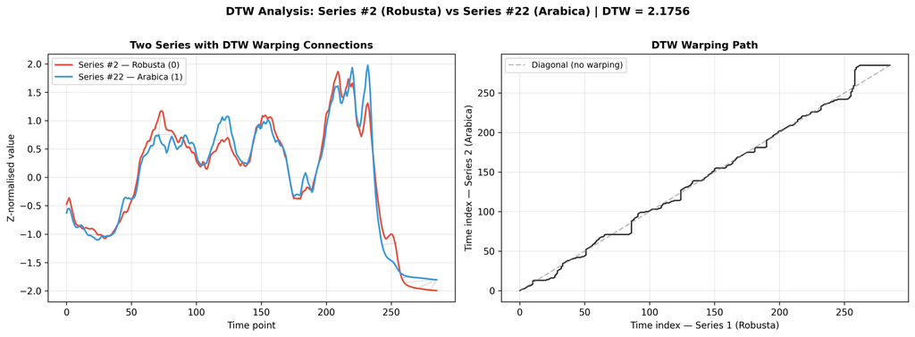

```python
dc_i, dc_j = 2, 22
s1 = znorm(X_train[dc_i])
s2 = znorm(X_train[dc_j])
dist, path = dtw_path(s1, s2)

fig, axes = plt.subplots(1, 2, figsize=(14, 5))

ax = axes[0]
t = np.arange(len(s1))
ax.plot(t, s1, color='#e74c3c', lw=1.8, label=f'Series #{dc_i} — Robusta (0)')
ax.plot(t, s2, color='#3498db', lw=1.8, label=f'Series #{dc_j} — Arabica (1)')
for pi, pj in path[::10]:
    ax.plot([pi, pj], [s1[pi], s2[pj]], color='gray', alpha=0.3, lw=0.8)
ax.set_title('Two Series with DTW Warping Connections', fontsize=11, fontweight='bold')
ax.set_xlabel('Time point')
ax.set_ylabel('Z-normalised value')
ax.legend(fontsize=9)
ax.grid(True, alpha=0.3)

ax2 = axes[1]
ax2.plot([p[0] for p in path], [p[1] for p in path], color='#2c2c2c', lw=1.5)
ax2.plot([0, len(s1)-1], [0, len(s2)-1], '--', color='gray', alpha=0.5, label='Diagonal (no warping)')
ax2.set_xlabel('Time index — Series 1 (Robusta)')
ax2.set_ylabel('Time index — Series 2 (Arabica)')
ax2.set_title('DTW Warping Path', fontsize=11, fontweight='bold')
ax2.legend(fontsize=9)
ax2.grid(True, alpha=0.3)

plt.suptitle(f'DTW Analysis: Series #{dc_i} (Robusta) vs Series #{dc_j} (Arabica) | DTW = {dist:.4f}',
             fontsize=12, fontweight='bold', y=1.01)
plt.tight_layout()
plt.show()
```

The warping path for Series #2 (Robusta) vs Series #22 (Arabica) stays close to the diagonal throughout, with moderate horizontal and vertical runs concentrated around time points 75–125 and 250–285, where the two spectra exhibit slight phase misalignments in their absorption peaks. This reveals that the two coffee types share a broadly similar spectroscopic shape but differ in the precise timing and sharpness of key features, which DTW successfully accounts for.

## 3.2 Sakoe-Chiba Window Selection

Use **leave-one-out cross-validation (LOO-CV)** on the training set to select the best Sakoe-Chiba band for 1-NN DTW. Evaluate $w \in \{0.05, 0.10, 0.20, 0.50\}$ (fraction of series length).

| Window $w$ | LOO-CV accuracy |
| --- | --- |
| 0.05 |  |
| 0.10 |  |
| 0.20 |  |
| 0.50 |  |

Plot LOO-CV accuracy vs. $w$ and mark the selected value.

**Report $w^*$** (the selected window) — you will use this in Parts 3 and 4.

*Does constraining the warping path help, hurt, or make no difference for your dataset? (2–3 sentences)*

```python
def loo_cv_dtw(X, y, window=None):
    n = len(X)
    correct = 0
    for i in range(n):
        test = znorm(X[i])
        best_dist, best_label = np.inf, -1
        for j in range(n):
            if i == j:
                continue
            d = dtw_distance(test, znorm(X[j]), window=window)
            if d < best_dist:
                best_dist = d
                best_label = y[j]
        if best_label == y[i]:
            correct += 1
    return correct / n

windows = [0.05, 0.10, 0.20, 0.50]
loo_accuracies = {w: loo_cv_dtw(X_train, y_train, window=w) for w in windows}

pd.DataFrame({
    'Window $w$': windows,
    'LOO-CV Accuracy': [f"{loo_accuracies[w]:.4f}" for w in windows]
}).set_index('Window $w$')
```

| Window $w$ | LOO-CV Accuracy |
| --- | --- |
| 0.05 | 0.9643 |
| 0.10 | 0.9643 |
| 0.20 | 0.9643 |
| 0.50 | 0.9643 |

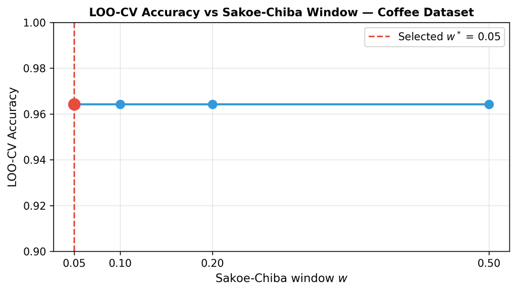

```
Selected w* = 0.05
```

```python
best_w = min(loo_accuracies, key=lambda w: (-loo_accuracies[w], w))

fig, ax = plt.subplots(figsize=(7, 4))
ax.plot(windows, [loo_accuracies[w] for w in windows], 'o-', color='#3498db', lw=2, markersize=8)
ax.axvline(x=best_w, color='#e74c3c', ls='--', lw=1.5, label=f'Selected $w^*$ = {best_w}')
ax.scatter([best_w], [loo_accuracies[best_w]], color='#e74c3c', s=120, zorder=5)
ax.set_xlabel('Sakoe-Chiba window $w$', fontsize=11)
ax.set_ylabel('LOO-CV Accuracy', fontsize=11)
ax.set_title('LOO-CV Accuracy vs Sakoe-Chiba Window — Coffee Dataset', fontsize=11, fontweight='bold')
ax.set_xticks(windows)
ax.set_ylim(0.90, 1.0)
ax.legend(fontsize=10)
ax.grid(True, alpha=0.3)
plt.tight_layout()
plt.show()

print(f"Selected w* = {best_w}")
```

## 3.3 Distance Matrix Visualisation

Compute the $n_\text{train} \times n_\text{train}$ pairwise distance matrix for your training set under Euclidean distance and DTW with $w = w^*$.

**TipComputational note**

If your training set has more than 100 series, use the first 50 training series (balanced across classes). State clearly how many you used.

For each matrix, produce a **heatmap** with rows and columns sorted by class label and class boundaries marked.

*Do the classes form visible clusters in either matrix? Does DTW produce cleaner separation than Euclidean for your dataset? (3–4 sentences)*

```python
sort_idx = np.argsort(y_train)
X_sorted = X_train[sort_idx]
y_sorted = y_train[sort_idx]
n_sorted = len(X_sorted)
boundary = np.sum(y_sorted == 0)

print(f"Using all {n_sorted} training series (28 < 100, no subsampling needed).")
print(f"Class 0 (Robusta): {boundary} series | Class 1 (Arabica): {n_sorted - boundary} series")

euc_mat = np.zeros((n_sorted, n_sorted))
for i in range(n_sorted):
    for j in range(n_sorted):
        euc_mat[i, j] = np.sqrt(np.sum((znorm(X_sorted[i]) - znorm(X_sorted[j]))**2))

best_w = 0.05
dtw_mat = np.zeros((n_sorted, n_sorted))
for i in range(n_sorted):
    for j in range(i, n_sorted):
        d = dtw_distance(znorm(X_sorted[i]), znorm(X_sorted[j]), window=best_w)
        dtw_mat[i, j] = d
        dtw_mat[j, i] = d
```

```
Using all 28 training series (28 < 100, no subsampling needed).
Class 0 (Robusta): 14 series | Class 1 (Arabica): 14 series
```

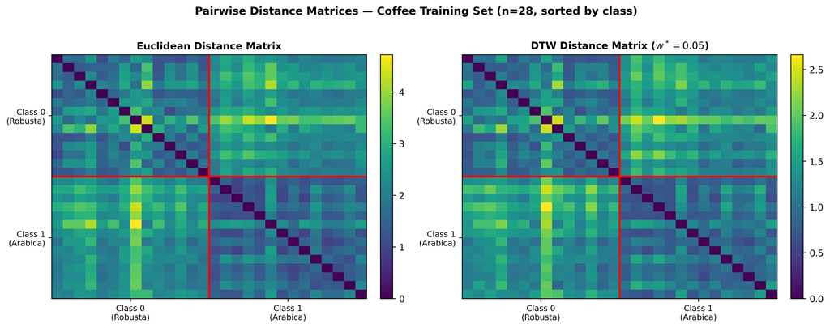

```python
fig, axes = plt.subplots(1, 2, figsize=(13, 5))

for ax, mat, title in zip(axes,
                           [euc_mat, dtw_mat],
                           ['Euclidean Distance Matrix',
                            f'DTW Distance Matrix ($w^*={best_w}$)']):
    im = ax.imshow(mat, cmap='viridis', aspect='auto')
    ax.axhline(y=boundary - 0.5, color='red', lw=2)
    ax.axvline(x=boundary - 0.5, color='red', lw=2)
    ax.set_xticks([boundary/2 - 0.5, boundary + (n_sorted - boundary)/2 - 0.5])
    ax.set_xticklabels(['Class 0\n(Robusta)', 'Class 1\n(Arabica)'], fontsize=9)
    ax.set_yticks([boundary/2 - 0.5, boundary + (n_sorted - boundary)/2 - 0.5])
    ax.set_yticklabels(['Class 0\n(Robusta)', 'Class 1\n(Arabica)'], fontsize=9)
    ax.set_title(title, fontsize=11, fontweight='bold')
    plt.colorbar(im, ax=ax, fraction=0.046, pad=0.04)

plt.suptitle('Pairwise Distance Matrices — Coffee Training Set (n=28, sorted by class)',
             fontsize=12, fontweight='bold', y=1.01)
plt.tight_layout()
plt.show()
```

# 4 Part 3 — Classification Benchmarking (25 pts)

## 4.1 Classifier Comparison

Apply the following four classifiers using the **standard UCR train/test split**. Report test accuracy and error rate for each.

| Classifier | Test accuracy | Test error |
| --- | --- | --- |
| 1-NN Euclidean |  |  |
| 1-NN DTW ($w = w^*$) |  |  |
| TSBF |  |  |
| MiniROCKET |  |  |
| **Majority-class baseline** |  |  |

*Compare your 1-NN DTW accuracy to the result published on the [UCR archive page](https://www.timeseriesclassification.com/) for your dataset. Are your numbers consistent? If not, identify the most likely cause. (2–3 sentences)*

## 4.2 SAX Histogram Classifier

Encode every training series as a SAX symbol-frequency histogram ($M = M_2$). Train a Random Forest on these histograms. Evaluate on the test set. Vary the alphabet size $a \in \{3, 4, 6, 8\}$:

| Alphabet size $a$ | Test accuracy |
| --- | --- |
| 3 |  |
| 4 |  |
| 6 |  |
| 8 |  |

*How does the SAX histogram classifier compare to the distance-based methods in §3.1? What information does the histogram representation discard? (3–4 sentences)*

## 4.3 Error Analysis

Using the **best-performing classifier** from §3.1, identify the 3 misclassified test series most similar to the wrong class (or most distant from the correct nearest neighbour under DTW).

For each misclassified series: plot it alongside its nearest training neighbour under DTW; state the true class, predicted class, and DTW distances to both classes’ nearest neighbours; give a one-sentence hypothesis for the misclassification.

*Is there a visual pattern to the errors? (2–3 sentences)*

# 5 Part 4 — Noise Robustness (10 pts)

Let $\hat\sigma$ be the overall standard deviation of your training series. For noise levels $\sigma_\text{noise} \in \{0.1,\ 0.3,\ 0.5\} \times \hat\sigma$, create noisy copies of **both** training and test sets:

$$x_t^{(\text{noisy})} = x_t + \varepsilon_t, \quad
\varepsilon_t \sim \mathcal{N}(0,\, \sigma_\text{noise}^2)$$

Use your student ID as the seed (a separate noise draw per series and level).

Re-train and evaluate **1-NN Euclidean** and **1-NN DTW ($w = w^*$)** at each noise level:

| $\sigma_\text{noise}/\hat\sigma$ | 1-NN Euclidean | 1-NN DTW |
| --- | --- | --- |
| 0 (original) |  |  |
| 0.1 |  |  |
| 0.3 |  |  |
| 0.5 |  |  |

Plot accuracy vs. noise level for both classifiers on the same axes.

*Which classifier degrades more gracefully? Is this consistent with the theoretical properties of DTW vs. Euclidean? (3–4 sentences)*

# 6 Part 5 — UWave Gesture Library: Multivariate k-NN (20 pts)

**ImportantCommon Task — All Students**

This part uses the **UWaveGestureLibrary** dataset — the same for all students. Download the three train/test files (X, Y, Z axes) from the [UCR archive](https://www.timeseriesclassification.com/description.php?Dataset=UWaveGestureLibraryAll). The dataset contains hand gesture trajectories recorded with a Wii-mote: **896 training series**, **3582 test series**, **8 gesture classes**, **315 time points per axis**.

## 6.1 Two Distance Measures

Propose two distance measures for comparing multivariate time series with three axes. A natural formulation sums per-axis distances:
$$d(Q, C) = d_X(Q_X, C_X) + d_Y(Q_Y, C_Y) + d_Z(Q_Z, C_Z)$$
where each $d_\cdot$ is Euclidean or DTW (with or without a constraint).

State your two chosen measures, including any hyperparameters, and justify why they are reasonable for gesture data. *(3–4 sentences)*

## 6.2 Cross-Validation for k

For each of your two distance measures, use **10-fold cross-validation on the training set** to find the value of $k \in \{1, 3, 5, 7\}$ that minimises classification error.

Report cross-validated error for each $(k, \text{distance})$ combination in a table and state the selected $k^*$ for each measure.

**TipComputational note**

DTW on 896 series of length 315 is expensive. If the full 10-fold CV is too slow, use a stratified random subset of 200 training series (25 per class). State clearly which you used.

## 6.3 Test-Set Evaluation

Using the selected $k^*$ for each distance measure, evaluate on the full test set. Report test accuracy, test error rate, and wall-clock runtime. Present predictions as an **8 × 8 confusion matrix** (rows = true class, columns = predicted class).

## 6.4 Axis Weighting

Is equal weighting of the X, Y, and Z axes reasonable for gesture recognition? What evidence from your confusion matrix or domain knowledge supports or challenges this assumption? What alternative weighting scheme could you try, and how would you select the weights? *(4–5 sentences)*

# 7 Part 6 — Decision Log (5 pts)

This section is graded on **specificity and honesty**. Generic statements receive no credit; statements that reference concrete numbers from your own output receive full credit.

Address the following three prompts in **200–300 words total**:

1. **One non-obvious finding** from Parts 1–2: something about your dataset’s geometry or its SAX representation that surprised you. Reference a specific number or figure.
2. **One tradeoff** you navigated: the choice of $w^*$, SAX alphabet size, or when to use DTW vs. Euclidean. Explain what evidence from *your data* drove the decision.
3. **One open question** your analysis raised. Name the dataset, the classifier, and the observed phenomenon you cannot yet explain.

*IE 48B — Special Topics in Time Series Analytics, Spring 2026* *Mustafa Gökçe Baydoğan*